# PA1_template

Michael O’Connor

January 10, 2016

# Course Project 1

1. Code for reading in the dataset and/or processing the data.

```r
activity <-read.csv("activity.csv")
Nbr_Missing_Rows <- is.na(activity$steps)
```

2. Calculate & report total, mean and median number of steps taken per day NOTE: For these calculations, we’ll ignore the missing values in the dataset

Histogram of the total steps for each day (with NA data removed)

```r
steps_day <- aggregate(activity$steps, by=list(date=activity$date), FUN=sum)
names(steps_day)[2]="steps"
total_steps <- sum(steps_day$steps, na.rm = TRUE)
mean_steps <- mean(steps_day$steps, na.rm = TRUE)
median_steps <- median(steps_day$steps, na.rm = TRUE)
mean_interval_steps <- as.integer(mean_steps/288)
sprintf("Total Steps = %g; Mean Steps per day = %7.2f Median Steps per day =  %g",total_steps, mean_steps,median_steps)
```

```
## [1] "Total Steps = 570608; Mean Steps per day = 10766.19 Median Steps per day =  10765"
```

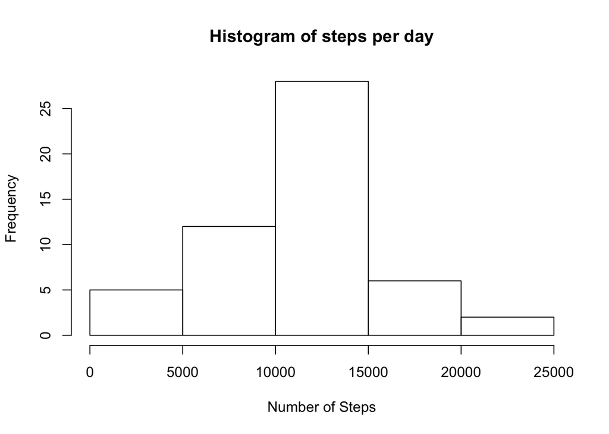

```r
hist(steps_day$steps,breaks=6,main="Histogram of steps per day",xlab="Number of Steps")
```

3. Handle NA values. I used a simple approach of replacing Step NAs with Mean of Steps/Interval
- Calculate and report the total number of missing values in the dataset (i.e. the total number of rows with 𝙽𝙰s)
- Devise a strategy for filling in all of the missing values in the dataset. The strategy does not need to be sophisticated. For example, you could use the mean/median for that day, or the mean for that 5-minute interval, etc.
- Create a new dataset that is equal to the original dataset but with the missing data filled in.

```r
Missing_Dates <- unique(activity$date[Nbr_Missing_Rows])
sprintf("Number of Missing Values in Dataset =  %g",sum(Nbr_Missing_Rows))
```

```
## [1] "Number of Missing Values in Dataset =  2304"
```

```r
print("Missing Dates:")
```

```
## [1] "Missing Dates:"
```

```r
sprintf("%s",as.character(Missing_Dates))
```

```
## [1] "2012-10-01" "2012-10-08" "2012-11-01" "2012-11-04" "2012-11-09"
## [6] "2012-11-10" "2012-11-14" "2012-11-30"
```

```r
activity2 <- activity      #New dataset
activity2$steps[Nbr_Missing_Rows]<- mean_interval_steps  #replace step NA with mean
```

3. What is the average daily activity pattern (per 5-minute interval)? NOTE: This section uses new dataset (activity2)
- Make a time series plot (i.e. 𝚝𝚢𝚙𝚎 = “𝚕”) of the 5-minute interval (x-axis) and the average number of steps taken, averaged across all days (y-axis)
- Which 5-minute interval, on average across all the days in the dataset, contains the maximum number of steps?

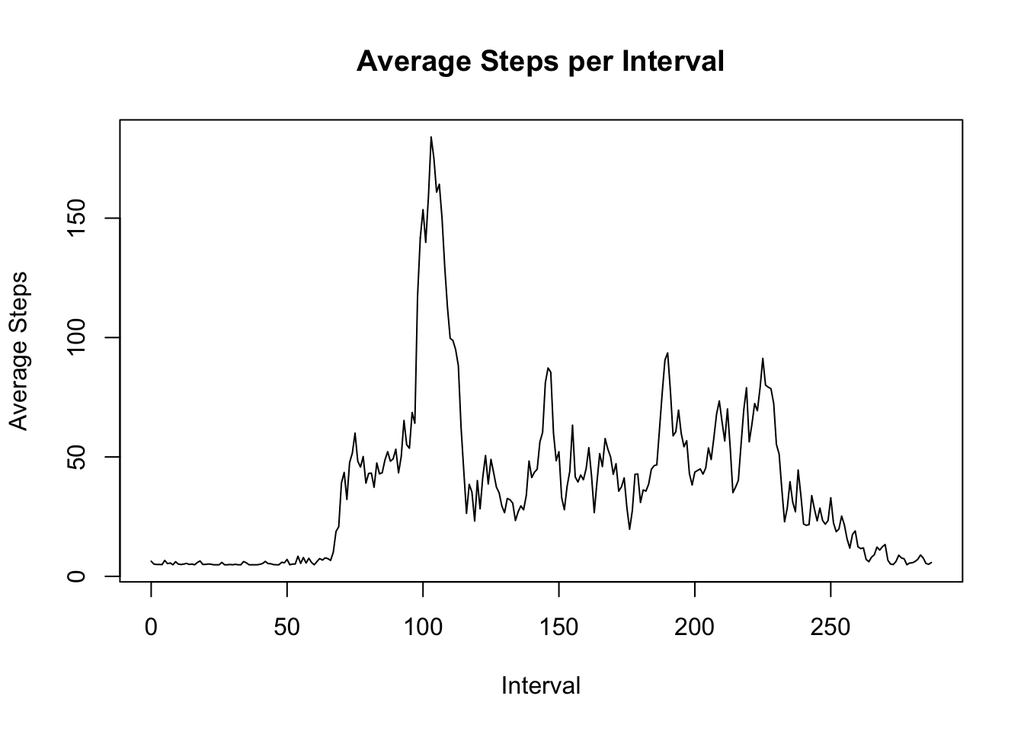

```r
steps_interval_day <-aggregate(activity2$steps,by=list(interval=activity2$interval), FUN=mean)
names(steps_interval_day)[2]="steps_int"
plot(c(0:287), steps_interval_day$steps_int, xlab="Interval",ylab="Average Steps",main="Average Steps per Interval", type="l")
```

```r
interval_location<- which.max(steps_interval_day$steps_int)
sprintf("The 5-minute interval that on average contains maximum steps is %g", interval_location)
```

```
## [1] "The 5-minute interval that on average contains maximum steps is 104"
```

4. Recalculate and plot using new dataset (activity2 - contains mean data in place of NA) Calculate and report the mean and median total number of steps taken per day.

```r
steps_day2 <- aggregate(activity2$steps, by=list(date=activity2$date), FUN=sum)
names(steps_day2)[2]="steps"
total_steps2 <- sum(steps_day2$steps)
mean_steps2 <- mean(steps_day2$steps)
median_steps2 <- median(steps_day2$steps)
sprintf("Recalculated Total Steps = %g; Mean Steps per day = %7.2f Median Steps per day =  %g",total_steps2, mean_steps2,median_steps2)
```

```
## [1] "Recalculated Total Steps = 655856; Mean Steps per day = 10751.74 Median Steps per day =  10656"
```

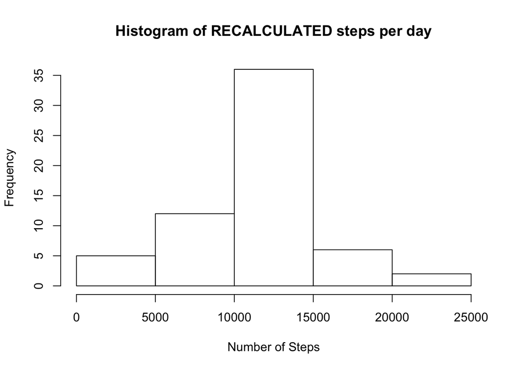

```r
hist(steps_day2$steps,breaks=6,main="Histogram of RECALCULATED steps per day",xlab="Number of Steps")
```

# Results & Discussion